# Home work 4

Volha Tryputsen

October 28, 2017

```r
library(tidyverse)
library(janitor) # clean names
library(knitr)
library(lubridate)
```

# Problem 2

```r
#dat_pols <- "../data/fivethirtyeight_datasets/pols-month.csv"
#dat_gdp <- "../data/fivethirtyeight_datasets/GDP.csv"

dat_pols <- "./pols-month.csv"
dat_gdp <- "./GDP.csv"
```

```r
data_pols =
  read_csv(dat_pols, col_types = "Dciiiciii") %>%
  clean_names()

data_pols_clean =
  data_pols %>%
  mutate(date = floor_date(mon, "month")) %>%
  mutate(president = as.character(ifelse(prez_dem=="1", "dem", "gop"))) %>%
  select(-c(mon, prez_dem, prez_gop)) %>%
  select(date, president, everything()) %>%
  arrange(date)

data_gdp =
  read_csv(dat_gdp) %>%
  clean_names()

data_gdp_clean =
  data_gdp %>%
  mutate(gdp = replace(value, value == ".", NA)) %>%
  mutate(gdp = as.numeric(gdp)) %>%
  select(-value)

data_p2 = full_join(data_pols_clean, data_gdp_clean)
```

Dataset `data_pols_clean` contains 822 observations and 8 variables (date, president, gov_gop, sen_gop, rep_gop, gov_dem, sen_dem, rep_dem) related to the number of national politicians who are democratic or republican at a given month and year between 1947-01-01 and 2015-06-01. During data cleaning step a new variable `president` was created which takes values dem, gop. Existing indicator variables `prez_dem` and `prez_gop` were used to creat variable `president`. However, only `prez_dem` variable was used for coding for variable `president` because `prez_gop` had values of `2` which is not recorded in variable descrtiption and thus could be either a coding mistake or, perhapse, a coding for missing values.  
Variable `date` was also created by collapsing `mon` variable to the first date of the month.

Dataset `data_gdp_clean` contains 273 observations and 2 variables (date, gdp) related to the value of GDP at a given month and year between 1947-01-01 and 2015-01-01.

Datasets `data_pols_clean` and `data_gdp_clean` were merged by `date` variable. The resulting dataset `data_p2` contains 822 observations and 9 variables.

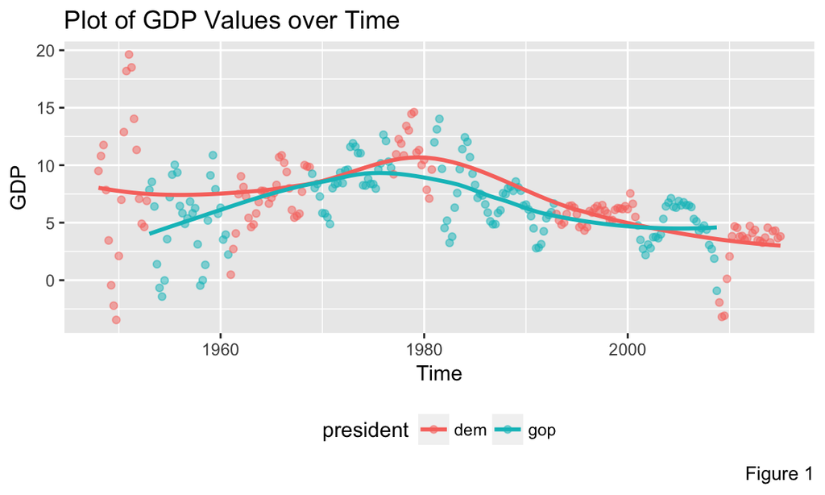

```r
data_p2%>%
  filter(!is.na(gdp) & !gdp == ".")%>%
    select(date, president, gdp)%>%
    ggplot(aes(x = date, y = gdp, color = president)) +
    geom_point(alpha = 0.5) +
    geom_smooth(se = FALSE) +
    theme(legend.position = "bottom")+
    labs(title = "Plot of GDP Values over Time",
         x = "Time",
         y = "GDP",
         caption = "Figure 1")
```